# R Workshop 1

Andrew Stewart

3/5/2018

# ANOVA and Regression

## ANOVA

At the start of your script, you need to make sure you load the packages you need for this workshop - they are: ggplot2, yarrr, psych, afex, emmeans, Hmisc, MASS, car, leaps, and readr. You can install and the load ggplot2 as follows:

install.packages (“ggplot2”)  
library (ggplot2)

Remember to install the rest of the packages. Once they are installed you can then load them into your library using the library(packagename) or require(packagename) functions.

```r
library (ggplot2) #Needed for graphing with ggplot
library (yarrr) #Needed to generate pirate plots
library (psych) #Needed for describeBy and to generate descriptives
library (afex) #Needed for factorial ANOVA
library (emmeans) #Needed to interpret interaction with contrasts and simple effects
require (Hmisc) #Needed for correlation
require (MASS) #Needed for maths functions
require (readr) #Needed to read in csv file
require (car) #Needed for VIF calculation
library (leaps) #Helps visualise multiple regression model fit
```

## Question 1

30 paricipants took part in a reaction time experiment. It was a between participants design with one factor - people had to fixate on a fixation cross and then respond to words that appeared in the bottom half of the screen versus the top half (coded as Low vs. High). We want to know whether RT differed as a function of our screen location of the target words. Here are the data you’ll be using in this first question - you can see we have Participants from 1-30, two Conditions (Low vs. High) and the Response Time in msec. Our datafile is called “data1”. When you import your data, remember to convert the Condition column to a factor with two levels (Low, High).

First plot the data with Condition on the x-axis and Response on the y-axis using ggplot.

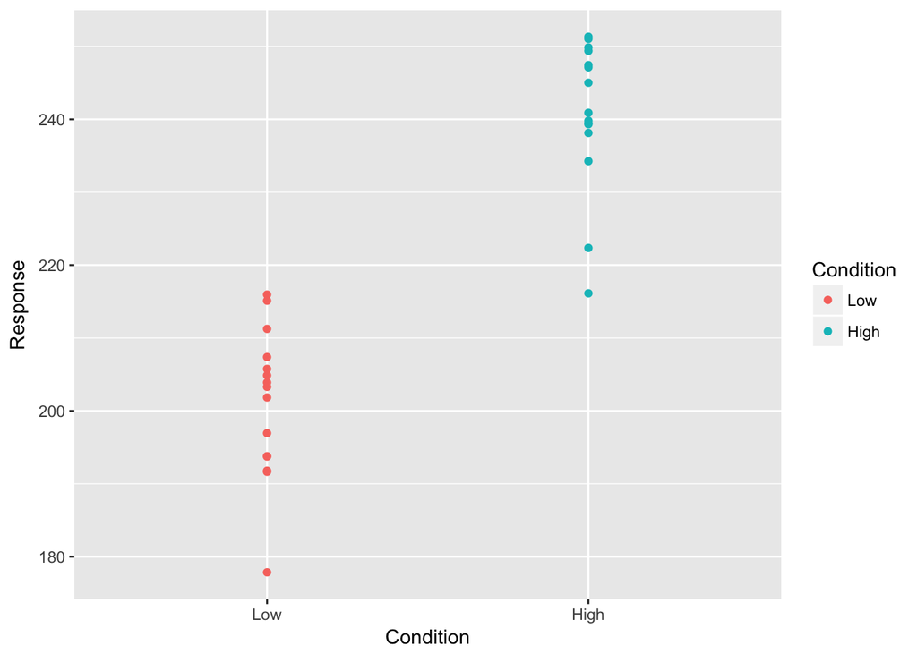

```r
p <- ggplot (data1, aes (x=Condition, y=Response, colour=Condition)) + geom_point()
p
```

Use the pirateplot function to plot an RDI plot.

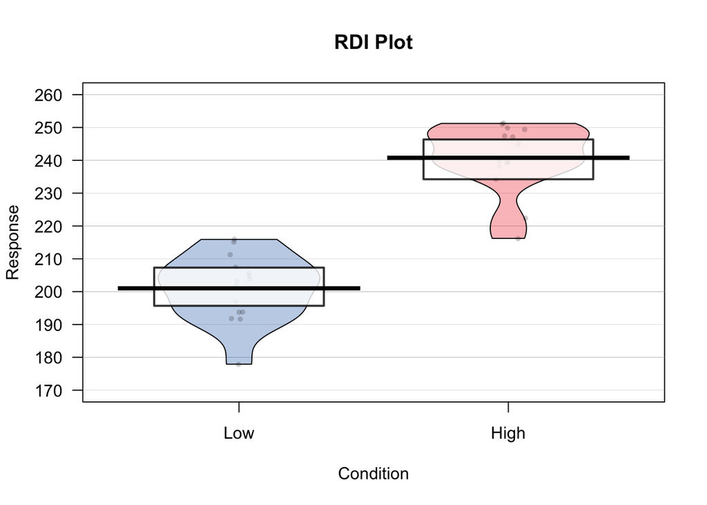

```r
p <- pirateplot (formula = Response ~ Condition,
                 data = data1,
                 xlab = "Condition",
                 ylab = "Response",
                 main = "RDI Plot")
```

You can change the theme of the plot to one of the pre-set ones by changing the parameter “theme” as below:

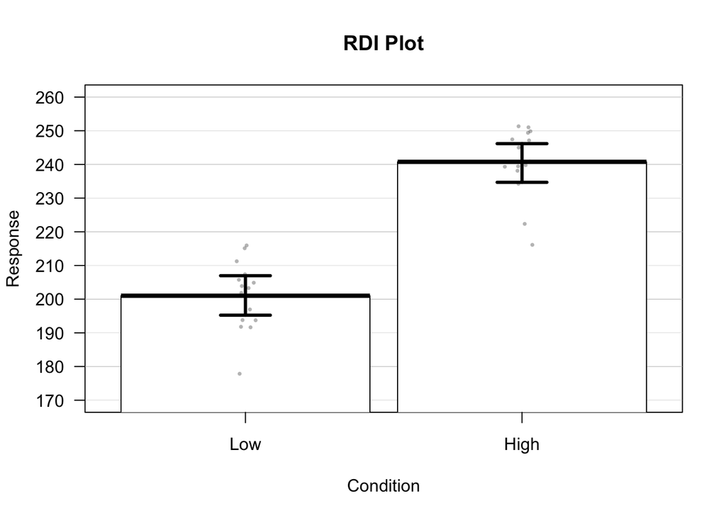

```r
p <- pirateplot (formula = Response ~ Condition,
                 data = data1,
                 xlab = "Condition",
                 ylab = "Response",
                 main = "RDI Plot",
                 theme=4)
```

Use the describeBy function in the psych package to generate descriptives grouped by Condition.

```r
describeBy(data1$Response, group=data1$Condition)
```

```
##
##  Descriptive statistics by group
## group: Low
##    vars  n   mean    sd median trimmed   mad    min    max range  skew
## X1    1 15 201.01 10.18  203.3  201.64 11.79 177.85 215.95  38.1 -0.45
##    kurtosis   se
## X1    -0.44 2.63
## --------------------------------------------------------
## group: High
##    vars  n   mean    sd median trimmed mad    min    max range  skew
## X1    1 15 240.77 10.27 240.89  241.85 9.7 216.13 251.33  35.2 -1.06
##    kurtosis   se
## X1     0.15 2.65
```

Run a between participants ANOVA to determine whether our conditions differ significantly from each other.

```r
model <- aov(Response~Condition, data=data1)
summary (model)
```

```
##             Df Sum Sq Mean Sq F value   Pr(>F)
## Condition    1  11857   11857   113.4 2.35e-11 ***
## Residuals   28   2927     105
## ---
## Signif. codes:  0 '***' 0.001 '**' 0.01 '*' 0.05 '.' 0.1 ' ' 1
```

## Question 2

In this experiment we have one betwen participants factor with three levels - the words were either synonyms for the word ‘Slow’, the word ‘Fast’ or were neutral. We think people might respond more quickly to words that mean ‘Fast’ and more slowly to words that mean ‘Slow’. We want to know whether people’s RTs varied as a function of our factor. We have three conditions (Slow, Fast, Neutral) and Response Time in msec. Our datafile is caled “data2”. Again, when you import the data remember to convert the Condition column to a factor - this time it has three levels (Slow, Fast, Neutral). Our data file is called data2.

```r
data2 <- read_csv("/Users/andrewstewart/Desktop/Air Work/R analyses/DNEP course/Day One scripts/data2.csv", col_types = cols(Condition = col_factor(levels = c("Fast",
    "Neutral", "Slow"))))
print (data2)
```

```
## # A tibble: 45 x 3
##    Participant Condition Response
##          <int> <fct>        <dbl>
##  1           1 Slow          11.9
##  2           2 Slow          12.4
##  3           3 Slow          12.9
##  4           4 Slow          11.8
##  5           5 Slow          12.3
##  6           6 Slow          12.4
##  7           7 Slow          12.6
##  8           8 Slow          12.2
##  9           9 Slow          13.1
## 10          10 Slow          12.2
## # ... with 35 more rows
```

Let’s generate a plot using ggplot2 and then an RDI plot using pirateplot.

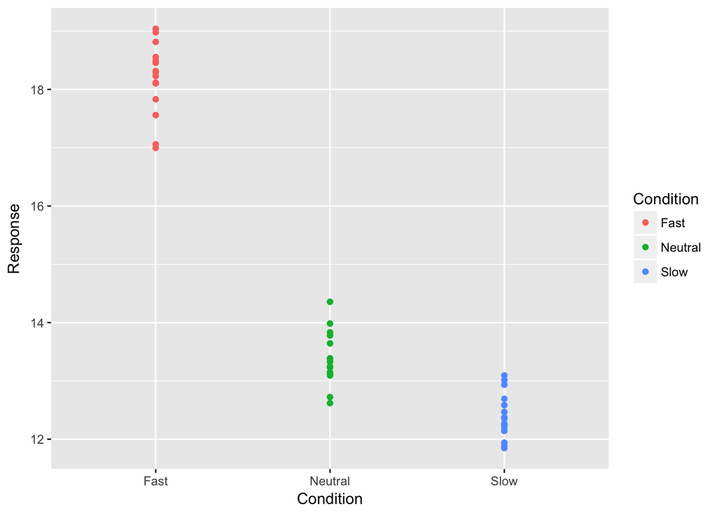

```r
p <- ggplot (data2, aes (x=Condition, y=Response, colour=Condition)) + geom_point()
p
```

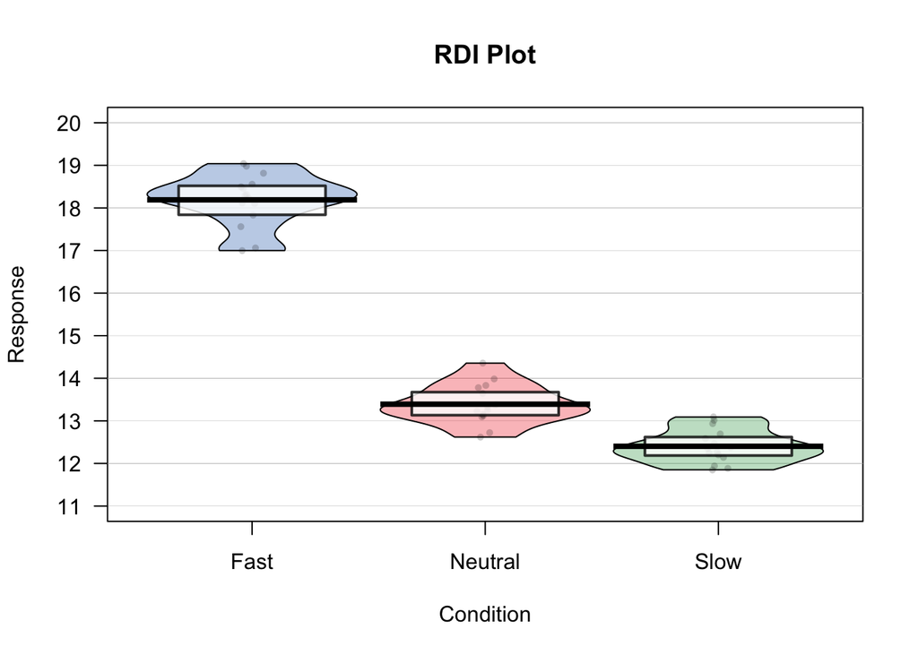

```r
p <- pirateplot (formula = Response ~ Condition,
                 data = data2,
                 xlab = "Condition",
                 ylab = "Response",
                 main = "RDI Plot")
```

Now for some descriptives…

```r
describeBy(data2$Response, group=data2$Condition)
```

```
##
##  Descriptive statistics by group
## group: Fast
##    vars  n  mean   sd median trimmed  mad min   max range  skew kurtosis
## X1    1 15 18.19 0.62  18.29   18.22 0.39  17 19.04  2.04 -0.57    -0.71
##      se
## X1 0.16
## --------------------------------------------------------
## group: Neutral
##    vars  n  mean   sd median trimmed  mad   min   max range skew kurtosis
## X1    1 15 13.39 0.46  13.33   13.38 0.35 12.62 14.36  1.74 0.29    -0.64
##      se
## X1 0.12
## --------------------------------------------------------
## group: Slow
##    vars  n mean  sd median trimmed  mad   min   max range skew kurtosis
## X1    1 15 12.4 0.4  12.35   12.39 0.34 11.85 13.09  1.25 0.32    -1.17
##     se
## X1 0.1
```

The means look pretty different from each other, but we need to run a between Ss ANOVA to find out if there’s a difference (somewhere) between our conditions.

```r
model <- aov (Response~Condition, data2)
summary (model)
```

```
##             Df Sum Sq Mean Sq F value Pr(>F)
## Condition    2 287.46  143.73   574.5 <2e-16 ***
## Residuals   42  10.51    0.25
## ---
## Signif. codes:  0 '***' 0.001 '**' 0.01 '*' 0.05 '.' 0.1 ' ' 1
```

We find that there is - the F value is 574 - so let’s follow this up with some pairwise comparisons using *emmeans* - let’s be conservative and use Bonferroni correction. Remember, if you ever forget the syntax for using a function you can type *> help (“functionname”)* or *> ? functionname* and information about the function (including syntax) will appear in the Help window.

```r
emmeans (model, pairwise~Condition, adjust="Bonferroni")
```

```
## $emmeans
##  Condition   emmean        SE df lower.CL upper.CL
##  Fast      18.18998 0.1291452 42 17.92936 18.45061
##  Neutral   13.39155 0.1291452 42 13.13093 13.65218
##  Slow      12.40295 0.1291452 42 12.14233 12.66358
##
## Confidence level used: 0.95
##
## $contrasts
##  contrast        estimate        SE df t.ratio p.value
##  Fast - Neutral 4.7984288 0.1826389 42  26.273  <.0001
##  Fast - Slow    5.7870268 0.1826389 42  31.686  <.0001
##  Neutral - Slow 0.9885981 0.1826389 42   5.413  <.0001
##
## P value adjustment: bonferroni method for 3 tests
```

## Question 3

Now let’s look at a 2 x 2 repeated measures design - we have 32 participants. Their task was to respond to an object that appeared on the screen. Before each object appeared, the word High (H) or Low (L) was presented. This is Factor_1. The object appeared either near the top of the screen (H) or towards the bottom (L). This is Factor_2. We predict that people will respond more quickly to objects that appear towards the top of screen after reading the word ‘High’ and more quickly to objects that appear towards the bottom of screen after reading the word ‘Low’. In other words, we predict our conditions HH and LL to be faster than LH and HL respectively. Our data file is called “data_twobytwo”

```r
data_twobytwo <- read_csv("/Users/andrewstewart/Desktop/Air Work/R analyses/DNEP course/Day One scripts/data_twobytwo.csv",col_types = cols(Factor_1 = col_factor(levels = c("L",
        "H")), Factor_2 = col_factor(levels = c("L",
        "H"))))
```

Let’s not print the data as there is quite a lot. Rather, let’s ask first for a plot…

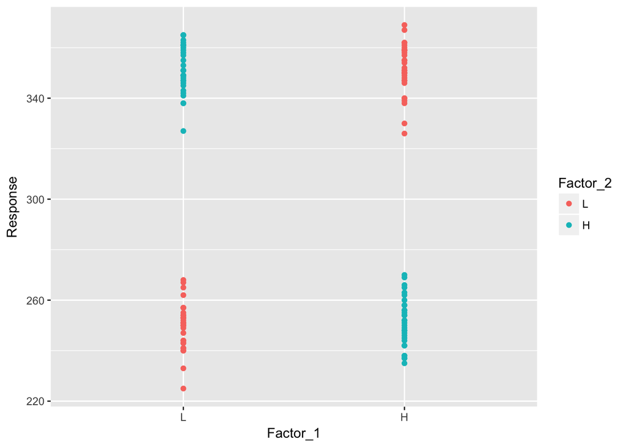

```r
p <- ggplot (data_twobytwo, aes (x=Factor_1, y=Response, colour=Factor_2)) + geom_point()
p
```

…and then ask for some descriptives…

```r
describeBy(data_twobytwo$Response, group=list (data_twobytwo$`Factor_1`, data_twobytwo$`Factor_2`))
```

```
##
##  Descriptive statistics by group
## : L
## : L
##    vars  n mean   sd median trimmed mad min max range  skew kurtosis   se
## X1    1 32  250 9.29    251  250.08 8.9 225 268    43 -0.31     0.28 1.64
## --------------------------------------------------------
## : H
## : L
##    vars  n   mean   sd median trimmed   mad min max range  skew kurtosis
## X1    1 32 351.56 9.95  351.5  352.23 10.38 326 369    43 -0.63        0
##      se
## X1 1.76
## --------------------------------------------------------
## : L
## : H
##    vars  n   mean   sd median trimmed   mad min max range  skew kurtosis
## X1    1 32 351.75 9.27    351  352.23 11.12 327 365    38 -0.43    -0.33
##      se
## X1 1.64
## --------------------------------------------------------
## : H
## : H
##    vars  n   mean   sd median trimmed  mad min max range skew kurtosis
## X1    1 32 251.47 9.72  251.5  251.27 9.64 235 270    35 0.11    -0.97
##      se
## X1 1.72
```

OK, now we need to run a factorial ANOVA. Remember, for factorial ANOVA we need to use the *aov_4* functionfrom the *afex* package. Here is our 2 x 2 ANOVA model:

```r
model <- aov_4(Response~Factor_1*Factor_2 + (1+Factor_1*Factor_2|Participant), data=data_twobytwo, na.RM=TRUE)
summary (model)
```

```
##
## Univariate Type III Repeated-Measures ANOVA Assuming Sphericity
##
##                     Sum Sq num Df Error SS den Df    F value Pr(>F)
## (Intercept)       11611983      1   2971.4     31 1.2115e+05 <2e-16 ***
## Factor_1                13      1   1653.1     31 2.4630e-01 0.6232
## Factor_2                22      1   3520.3     31 1.9330e-01 0.6633
## Factor_1:Factor_2   325927      1   3189.1     31 3.1683e+03 <2e-16 ***
## ---
## Signif. codes:  0 '***' 0.001 '**' 0.01 '*' 0.05 '.' 0.1 ' ' 1
```

To interpret the interaction we need to run some pairwise comparisons. We will ask for uncorrected p-values, but remember we then need to double the observed p-value (as we have two theoretically meanignful comparisons - HH vs. LH, and LL vs. HL)

```r
emmeans (model, pairwise~Factor_1*Factor_2, adjust="none")
```

```
## $emmeans
##  Factor_1 Factor_2   emmean       SE     df lower.CL upper.CL
##  L        L        250.0000 1.690063 116.69 246.6528 253.3472
##  H        L        351.5625 1.690063 116.69 348.2153 354.9097
##  L        H        351.7500 1.690063 116.69 348.4028 355.0972
##  H        H        251.4687 1.690063 116.69 248.1216 254.8159
##
## Confidence level used: 0.95
##
## $contrasts
##  contrast    estimate       SE    df t.ratio p.value
##  L,L - H,L -101.56250 2.209349 56.33 -45.969  <.0001
##  L,L - L,H -101.75000 2.600667 61.85 -39.125  <.0001
##  L,L - H,H   -1.46875 2.283669 54.85  -0.643  0.5228
##  H,L - L,H   -0.18750 2.283669 54.85  -0.082  0.9349
##  H,L - H,H  100.09375 2.600667 61.85  38.488  <.0001
##  L,H - H,H  100.28125 2.209349 56.33  45.390  <.0001
```

Even when we double the p-values, we find the HH vs. LH and the LL vs. HL comparisons are significant. We can conclude that peoeple respond quickly to objects that appear towards the top of the screen when preceeded by the word “High” (compared to “Low”), and respond quickly to objects that appear towards the bottom of the screen when preceeded by the word “Low” (compared to “High”).

# Multiple Regression

## Multiple Regression (Standard Method)

In standard multiple regression all the independent variables (IVs) are entered into the equation and evaluated for their contribution at the same time. Let’s work through a specific example.

An educational psychologist conducted a study that investigated the psycholinguistic variables that contribute to spelling performance in primary school children aged between 7- and 9-years. The researcher presented children with 48 words that varied systematically according to certain features such as age of acquisition, word frequency, word length, and imageability. The psychologist wants to check whether performance on the test accurately reflected children’s spelling ability as estimated by a standardised spelling test. That is, the psychologist wants to check whether her test was appropriate.

Children’s chronological age (in months) (age), their reading age (RA), their standardised reading age (std_RA), and their standardised spelling score (std_SPELL) were chosen as predictor variables. The criterion variable (Y) was the percentage correct spelling (corr_spell) score attained by each child using the list of 48 words.

You now need to read in the data file - if you can’t remember the path of where it is save, click on the ‘Import Dataset’ icon in the top right pane of R Studio. Make sure your data is assigned to the variable MRes_tut2 (which it should be automatically).

Before we start, let’s look at the relationships between our IVs (predictors) and our DV (outcome). We can plot graphs depicting the correlations. We’ll plot test performance against each of our four predictors in turn:

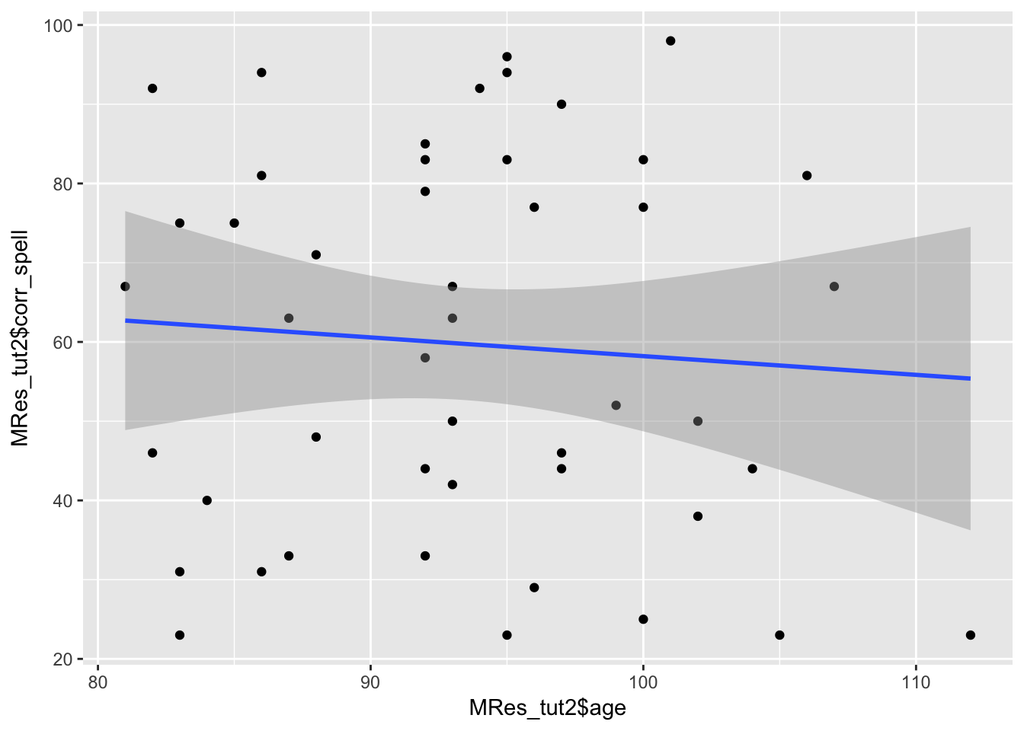

```r
ggplot (MRes_tut2, aes (x=MRes_tut2$age, y=MRes_tut2$corr_spell)) + geom_point() + geom_smooth(method="lm")
```

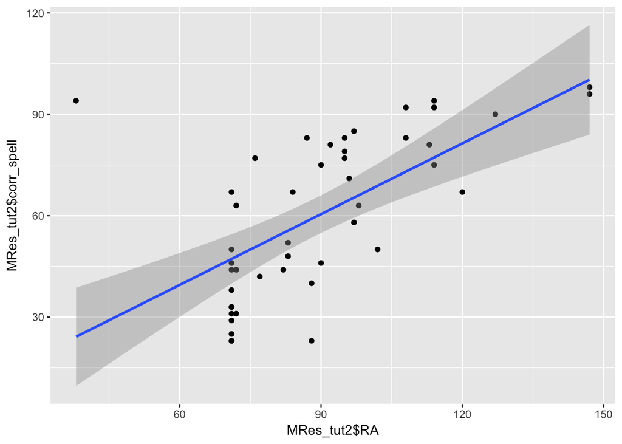

```r
ggplot (MRes_tut2, aes (x=MRes_tut2$RA, y=MRes_tut2$corr_spell)) + geom_point() + geom_smooth(method="lm")
```

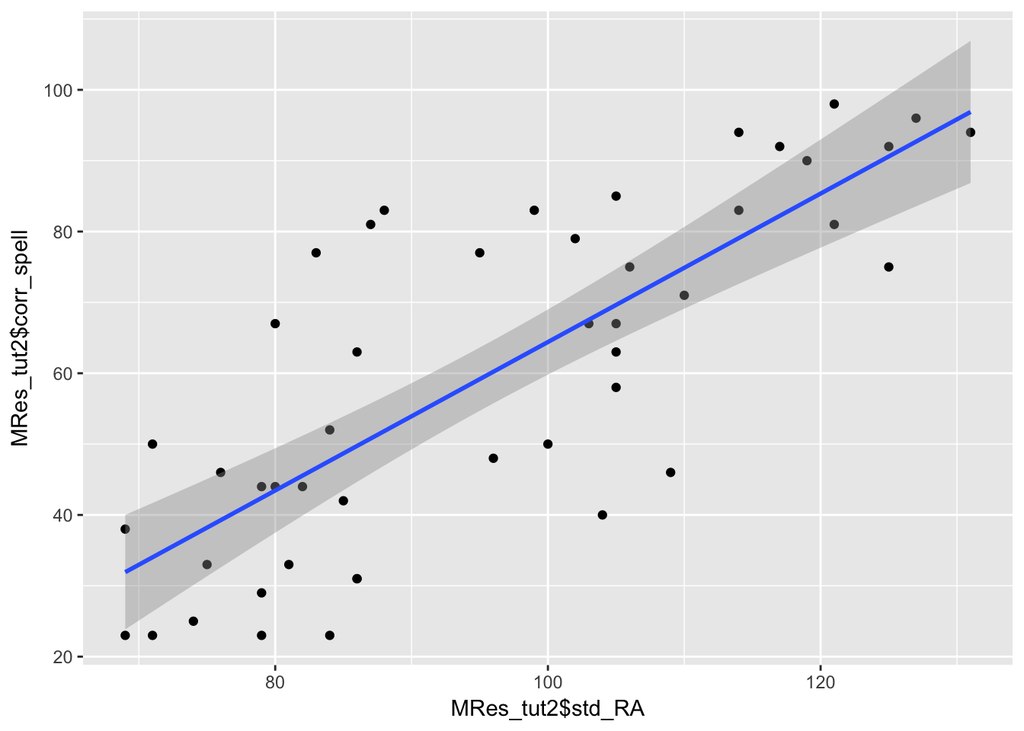

```r
ggplot (MRes_tut2, aes (x=MRes_tut2$std_RA, y=MRes_tut2$corr_spell)) + geom_point() + geom_smooth(method="lm")
```

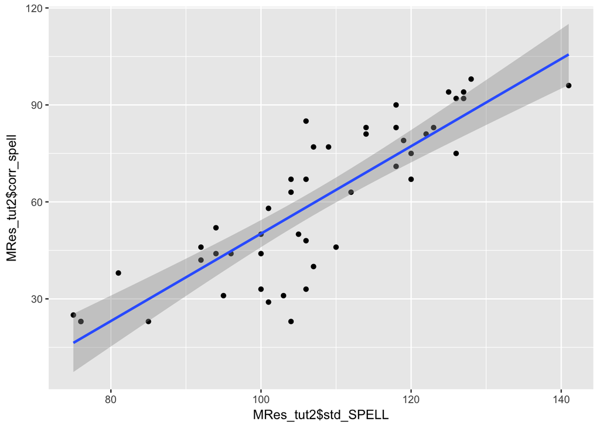

```r
ggplot (MRes_tut2, aes (x=MRes_tut2$std_SPELL, y=MRes_tut2$corr_spell)) + geom_point() + geom_smooth(method="lm")
```

Note the fact that chronological age does not seem to correlate with our outcome variable - we’ll return to this later…

We are going to do hierarchical regression first - we’ll build one model (which we’ll call model0) that is the mean of our outcome variable, and another model (model1) which contains all our predictors:

```r
model0 <- lm (corr_spell ~ 1, data=MRes_tut2)
model1 <- lm (corr_spell ~ age + RA + std_RA + std_SPELL, data=MRes_tut2)
```

Let’s compare them to each other:

```r
anova (model0, model1)
```

|  | Res.Df | RSS | Df | Sum of Sq | F | Pr(>F) |
| --- | --- | --- | --- | --- | --- | --- |
| 1 | 46 | 26348.426 | NA | NA | NA | NA |
| 2 | 42 | 3901.149 | 4 | 22447.28 | 60.41718 | 7.168748e-17 |

OK, so they differ - now let’s plot information about model fit - remember, we are particularly interested in Cook’s distance values for our case…

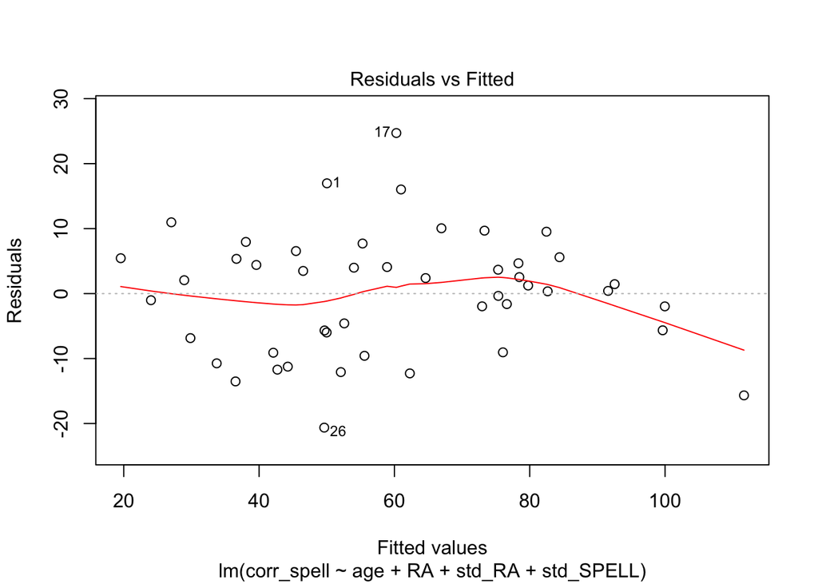

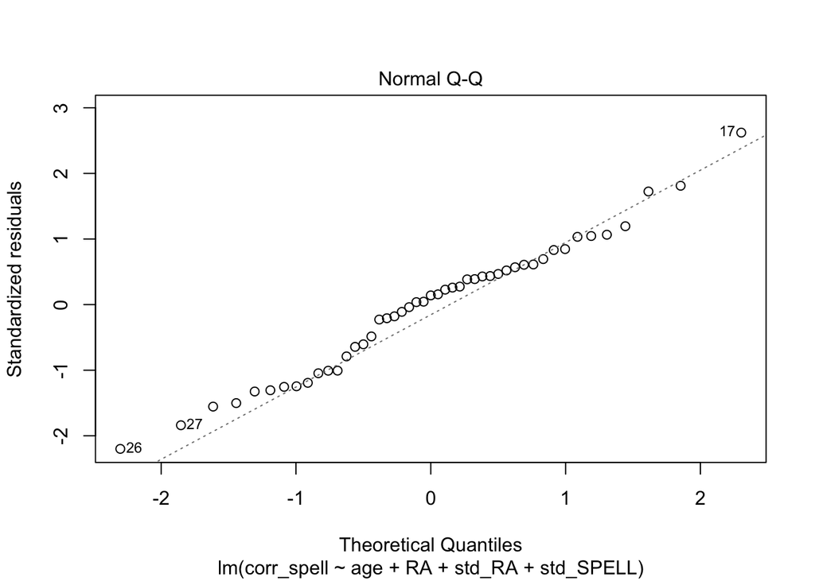

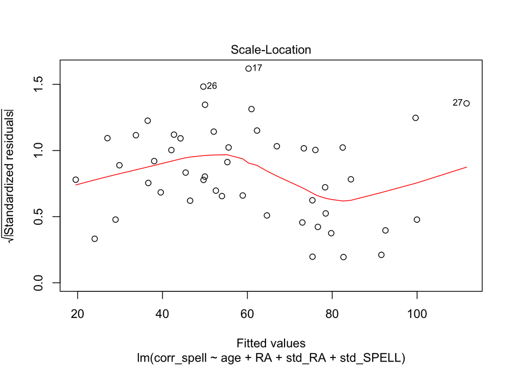

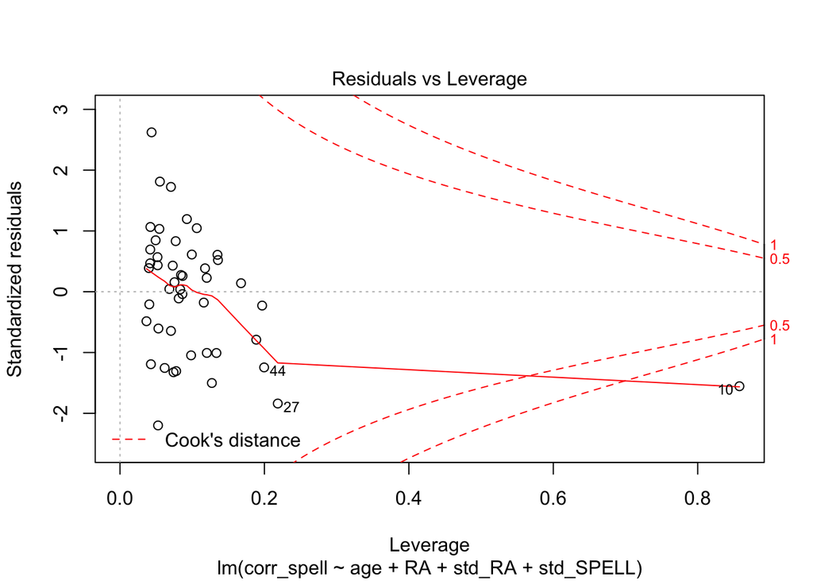

```r
plot (model1)
```

The errors looks fairly equally distributed along our fitted values (homoscedasticity) - although a little worse for high fitted values - and from the Q-Q plot we can tell they look fairly normal (they should follow the diagonal). How about influential cases? So, Case 10 looks a bit dodgy - it has a high Cook’s Distance value - which suggests it is having a disproportionate effect on our model. Let’s exclude it - we are creating a variable here which takes on logical values of TRUE and FALSE - the symbol != means ‘does not equal’ so we are creating a vector to act as a filter to filiter out Case 10.

```r
index <- MRes_tut2$case!=10
```

If you now type ‘index’ you see a list of TRUE and FALSE values. The FALSE value corresponds to Case 10.

```r
index
```

```
##  [1]  TRUE  TRUE  TRUE  TRUE  TRUE  TRUE  TRUE  TRUE  TRUE FALSE  TRUE
## [12]  TRUE  TRUE  TRUE  TRUE  TRUE  TRUE  TRUE  TRUE  TRUE  TRUE  TRUE
## [23]  TRUE  TRUE  TRUE  TRUE  TRUE  TRUE  TRUE  TRUE  TRUE  TRUE  TRUE
## [34]  TRUE  TRUE  TRUE  TRUE  TRUE  TRUE  TRUE  TRUE  TRUE  TRUE  TRUE
## [45]  TRUE  TRUE  TRUE
```

We now create another model (model2) which doesn’t include Case 10. Note we do this by applying the vector assigned to our variable we called index to our data set - this effectively acts as a filter to filter out Case 10 from our analyses.

```r
model2 <- lm (corr_spell ~ age + RA + std_RA + std_SPELL, data=MRes_tut2[index,])
```

Now, let’s check for multicollinearity measured by VIF:

```r
vif (model2)
```

```
##       age        RA    std_RA std_SPELL
##  3.843462 14.763168 14.672084  3.140457
```

It looks like RA and std_RA are problematic. We can look at the correlation between them using the rcorr function:

```r
rcorr (MRes_tut2$RA, MRes_tut2$std_RA)
```

```
##      x    y
## x 1.00 0.68
## y 0.68 1.00
##
## n= 47
##
##
## P
##   x  y
## x     0
## y  0
```

The correlation is pretty high (0.68), so let’s exclude the predictor with the highest VIF value (which is RA) and build a new model:

```r
model3 <- lm (corr_spell ~ age + std_RA + std_SPELL, data=MRes_tut2[index,])
vif (model3)
```

```
##       age    std_RA std_SPELL
##  1.190827  2.636186  2.821235
```

These values look ok now. Let’s generate the coefficients as this looks like a sensible model.

```r
summary (model3)
```

```
##
## Call:
## lm(formula = corr_spell ~ age + std_RA + std_SPELL, data = MRes_tut2[index,
##     ])
##
## Residuals:
##     Min      1Q  Median      3Q     Max
## -19.801  -6.907   1.327   5.155  24.669
##
## Coefficients:
##              Estimate Std. Error t value Pr(>|t|)
## (Intercept) -209.4400    26.7210  -7.838 9.43e-10 ***
## age            1.1033     0.2133   5.172 6.09e-06 ***
## std_RA         0.3804     0.1385   2.747  0.00883 **
## std_SPELL      1.2107     0.1650   7.339 4.78e-09 ***
## ---
## Signif. codes:  0 '***' 0.001 '**' 0.01 '*' 0.05 '.' 0.1 ' ' 1
##
## Residual standard error: 9.824 on 42 degrees of freedom
## Multiple R-squared:  0.8388, Adjusted R-squared:  0.8273
## F-statistic: 72.87 on 3 and 42 DF,  p-value: < 2.2e-16
```

```r
model0 <- lm (corr_spell ~ 1, data=MRes_tut2[index,])

anova (model3, model0)
```

|  | Res.Df | RSS | Df | Sum of Sq | F | Pr(>F) |
| --- | --- | --- | --- | --- | --- | --- |
| 1 | 42 | 4053.508 | NA | NA | NA | NA |
| 2 | 45 | 25150.978 | -3 | -21097.47 | 72.86641 | 1.090739e-16 |

We’d write our equation as something like:

Spelled correct = -209.44 + 1.10(age) + 0.38(std_RA) + 1.21(std_SPELL) + residual

## Sequential Regression

We can build up our models gradually by adding one new predictor at a time - note, because we know that the RA and std_RA predictors correlate highly, we have dropped the RA one. Let’s also get rid of problematic Case 10.

```r
index <- MRes_tut2$case!=10

model0 <- lm (corr_spell ~ 1, data=MRes_tut2[index,])
model1 <- lm (corr_spell ~ std_RA, data=MRes_tut2[index,])
model2 <- lm (corr_spell ~ std_RA + age, data=MRes_tut2[index,])
model3 <- lm (corr_spell ~ std_RA + age + std_SPELL, data=MRes_tut2[index,])
```

We can now compare the models with each each sequentially:

```r
anova (model0, model1)
```

|  | Res.Df | RSS | Df | Sum of Sq | F | Pr(>F) |
| --- | --- | --- | --- | --- | --- | --- |
| 1 | 45 | 25150.98 | NA | NA | NA | NA |
| 2 | 44 | 10370.88 | 1 | 14780.09 | 62.70672 | 5.278679e-10 |

```r
anova (model1, model2)
```

|  | Res.Df | RSS | Df | Sum of Sq | F | Pr(>F) |
| --- | --- | --- | --- | --- | --- | --- |
| 1 | 44 | 10370.884 | NA | NA | NA | NA |
| 2 | 43 | 9251.806 | 1 | 1119.078 | 5.201186 | 0.02758725 |

```r
anova (model2, model3)
```

|  | Res.Df | RSS | Df | Sum of Sq | F | Pr(>F) |
| --- | --- | --- | --- | --- | --- | --- |
| 1 | 43 | 9251.806 | NA | NA | NA | NA |
| 2 | 42 | 4053.508 | 1 | 5198.298 | 53.86162 | 4.777624e-09 |

Each sequential comparison indicates they are getting better - and this is what SPSS does when we build our models block by block - we are looking for improvement in the F-ratio. We should check the AIC values to be sure:

```r
AIC (model0)
```

```
## [1] 424.5268
```

```r
AIC (model1)
```

```
## [1] 385.7757
```

```r
AIC (model2)
```

```
## [1] 382.5232
```

```r
AIC (model3)
```

```
## [1] 346.5624
```

So, it looks like model3 is the best - it has the lowest AIC value too.

## Statistical regression

We can also do stepwise regression - forwards is when you start with the null model and predictors are added until they don’t explain any more variance, backwards is when you start with the full model and remove predictors until removal starts affecting your model’s predictive ability. Let’s drop case 10 and the high VIF predictor (RA). This is handy for models with lots of predictors where the order in sequential regression is not obvious.

```r
model0 <- lm (corr_spell ~ 1, data=MRes_tut2[index,])
model1 <- lm (corr_spell ~ age + std_RA + std_SPELL, data=MRes_tut2[index,])
```

Let’s do Stepwise forwards:

```r
steplimitsf <- step (model0, scope=list (lower=model0, upper=model1), direction="forward")
```

```
## Start:  AIC=291.98
## corr_spell ~ 1
##
##             Df Sum of Sq     RSS    AIC
## + std_SPELL  1   17802.2  7348.8 237.39
## + std_RA     1   14780.1 10370.9 253.23
## <none>                   25151.0 291.98
## + age        1      48.7 25102.3 293.89
##
## Step:  AIC=237.39
## corr_spell ~ std_SPELL
##
##          Df Sum of Sq    RSS    AIC
## + age     1   2567.20 4781.6 219.62
## + std_RA  1    714.14 6634.7 234.69
## <none>                7348.8 237.39
##
## Step:  AIC=219.62
## corr_spell ~ std_SPELL + age
##
##          Df Sum of Sq    RSS    AIC
## + std_RA  1     728.1 4053.5 214.02
## <none>                4781.6 219.62
##
## Step:  AIC=214.02
## corr_spell ~ std_SPELL + age + std_RA
```

```r
summary (steplimitsf)
```

```
##
## Call:
## lm(formula = corr_spell ~ std_SPELL + age + std_RA, data = MRes_tut2[index,
##     ])
##
## Residuals:
##     Min      1Q  Median      3Q     Max
## -19.801  -6.907   1.327   5.155  24.669
##
## Coefficients:
##              Estimate Std. Error t value Pr(>|t|)
## (Intercept) -209.4400    26.7210  -7.838 9.43e-10 ***
## std_SPELL      1.2107     0.1650   7.339 4.78e-09 ***
## age            1.1033     0.2133   5.172 6.09e-06 ***
## std_RA         0.3804     0.1385   2.747  0.00883 **
## ---
## Signif. codes:  0 '***' 0.001 '**' 0.01 '*' 0.05 '.' 0.1 ' ' 1
##
## Residual standard error: 9.824 on 42 degrees of freedom
## Multiple R-squared:  0.8388, Adjusted R-squared:  0.8273
## F-statistic: 72.87 on 3 and 42 DF,  p-value: < 2.2e-16
```

Stepwise backwards:

```r
steplimitsb <- step(model1, direction = "back")
```

```
## Start:  AIC=214.02
## corr_spell ~ age + std_RA + std_SPELL
##
##             Df Sum of Sq    RSS    AIC
## <none>                   4053.5 214.02
## - std_RA     1     728.1 4781.6 219.62
## - age        1    2581.2 6634.7 234.69
## - std_SPELL  1    5198.3 9251.8 249.98
```

```r
summary (steplimitsb)
```

```
##
## Call:
## lm(formula = corr_spell ~ age + std_RA + std_SPELL, data = MRes_tut2[index,
##     ])
##
## Residuals:
##     Min      1Q  Median      3Q     Max
## -19.801  -6.907   1.327   5.155  24.669
##
## Coefficients:
##              Estimate Std. Error t value Pr(>|t|)
## (Intercept) -209.4400    26.7210  -7.838 9.43e-10 ***
## age            1.1033     0.2133   5.172 6.09e-06 ***
## std_RA         0.3804     0.1385   2.747  0.00883 **
## std_SPELL      1.2107     0.1650   7.339 4.78e-09 ***
## ---
## Signif. codes:  0 '***' 0.001 '**' 0.01 '*' 0.05 '.' 0.1 ' ' 1
##
## Residual standard error: 9.824 on 42 degrees of freedom
## Multiple R-squared:  0.8388, Adjusted R-squared:  0.8273
## F-statistic: 72.87 on 3 and 42 DF,  p-value: < 2.2e-16
```

And stepwise using both forwards and backwards procedures:

```r
steplimitsboth <- step(model0, scope=list (upper=model1), direction = "both")
```

```
## Start:  AIC=291.98
## corr_spell ~ 1
##
##             Df Sum of Sq     RSS    AIC
## + std_SPELL  1   17802.2  7348.8 237.39
## + std_RA     1   14780.1 10370.9 253.23
## <none>                   25151.0 291.98
## + age        1      48.7 25102.3 293.89
##
## Step:  AIC=237.39
## corr_spell ~ std_SPELL
##
##             Df Sum of Sq     RSS    AIC
## + age        1    2567.2  4781.6 219.62
## + std_RA     1     714.1  6634.7 234.69
## <none>                    7348.8 237.39
## - std_SPELL  1   17802.2 25151.0 291.98
##
## Step:  AIC=219.62
## corr_spell ~ std_SPELL + age
##
##             Df Sum of Sq     RSS    AIC
## + std_RA     1     728.1  4053.5 214.02
## <none>                    4781.6 219.62
## - age        1    2567.2  7348.8 237.39
## - std_SPELL  1   20320.7 25102.3 293.89
##
## Step:  AIC=214.02
## corr_spell ~ std_SPELL + age + std_RA
##
##             Df Sum of Sq    RSS    AIC
## <none>                   4053.5 214.02
## - std_RA     1     728.1 4781.6 219.62
## - age        1    2581.2 6634.7 234.69
## - std_SPELL  1    5198.3 9251.8 249.98
```

```r
summary (steplimitsboth)
```

```
##
## Call:
## lm(formula = corr_spell ~ std_SPELL + age + std_RA, data = MRes_tut2[index,
##     ])
##
## Residuals:
##     Min      1Q  Median      3Q     Max
## -19.801  -6.907   1.327   5.155  24.669
##
## Coefficients:
##              Estimate Std. Error t value Pr(>|t|)
## (Intercept) -209.4400    26.7210  -7.838 9.43e-10 ***
## std_SPELL      1.2107     0.1650   7.339 4.78e-09 ***
## age            1.1033     0.2133   5.172 6.09e-06 ***
## std_RA         0.3804     0.1385   2.747  0.00883 **
## ---
## Signif. codes:  0 '***' 0.001 '**' 0.01 '*' 0.05 '.' 0.1 ' ' 1
##
## Residual standard error: 9.824 on 42 degrees of freedom
## Multiple R-squared:  0.8388, Adjusted R-squared:  0.8273
## F-statistic: 72.87 on 3 and 42 DF,  p-value: < 2.2e-16
```

You’ll see that the same final model is arrived it in each case. We have three significant predictors.

We can also use the stepAIC function - it will produce the same result as using the step function (as the step function bases model selection on AIC rather than F-ratio improvement). Step is actually a slightly simplified version of the stepAIC function.

```r
stepAICmodel <- stepAIC(model1, scope=model1, scale = 0,
        direction = "both",
        trace = 1, keep = NULL, steps = 1000,
        k = 2)
```

```
## Start:  AIC=214.02
## corr_spell ~ age + std_RA + std_SPELL
##
##             Df Sum of Sq    RSS    AIC
## <none>                   4053.5 214.02
## - std_RA     1     728.1 4781.6 219.62
## - age        1    2581.2 6634.7 234.69
## - std_SPELL  1    5198.3 9251.8 249.98
```

```r
summary (stepAICmodel)
```

```
##
## Call:
## lm(formula = corr_spell ~ age + std_RA + std_SPELL, data = MRes_tut2[index,
##     ])
##
## Residuals:
##     Min      1Q  Median      3Q     Max
## -19.801  -6.907   1.327   5.155  24.669
##
## Coefficients:
##              Estimate Std. Error t value Pr(>|t|)
## (Intercept) -209.4400    26.7210  -7.838 9.43e-10 ***
## age            1.1033     0.2133   5.172 6.09e-06 ***
## std_RA         0.3804     0.1385   2.747  0.00883 **
## std_SPELL      1.2107     0.1650   7.339 4.78e-09 ***
## ---
## Signif. codes:  0 '***' 0.001 '**' 0.01 '*' 0.05 '.' 0.1 ' ' 1
##
## Residual standard error: 9.824 on 42 degrees of freedom
## Multiple R-squared:  0.8388, Adjusted R-squared:  0.8273
## F-statistic: 72.87 on 3 and 42 DF,  p-value: < 2.2e-16
```

In this case, the model with the lowest AIC value is also the one arrived at statisically via the sequential procedure - but this may not always be the case.

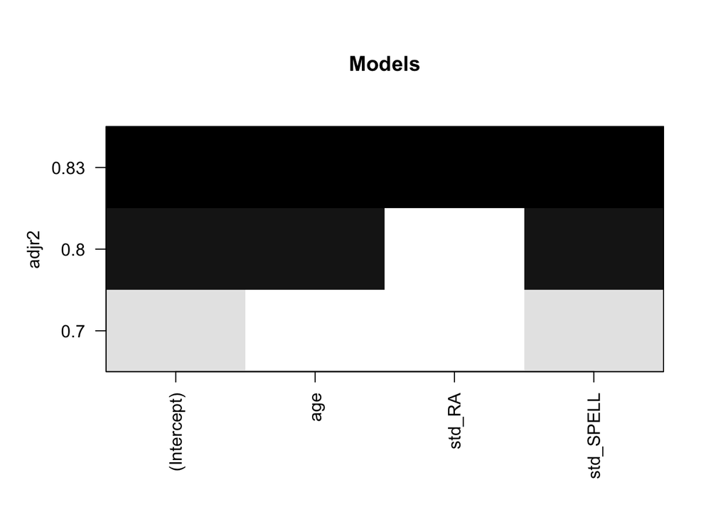

```r
leapsmodels <- regsubsets (corr_spell ~ age + std_RA + std_SPELL, data=MRes_tut2[index,])
plot (leapsmodels, scale="adjr2", main="Models")
```

If you look back to the initial plots we did, you might have noticed that chronological age did not seem to correlate with our outcome measure. Perhaps chronological age is acting as a suppressor - let’s build a model without it.

```r
modelx <- lm (corr_spell ~ std_RA + std_SPELL, data=MRes_tut2[index,])

AIC (modelx)
```

```
## [1] 367.2278
```

```r
AIC (stepAICmodel)
```

```
## [1] 346.5624
```

```r
summary (modelx)
```

```
##
## Call:
## lm(formula = corr_spell ~ std_RA + std_SPELL, data = MRes_tut2[index,
##     ])
##
## Residuals:
##     Min      1Q  Median      3Q     Max
## -27.393  -8.080   1.543   7.880  22.828
##
## Coefficients:
##             Estimate Std. Error t value Pr(>|t|)
## (Intercept) -82.5500    13.3799  -6.170 2.07e-07 ***
## std_RA        0.3767     0.1751   2.151   0.0371 *
## std_SPELL     0.9921     0.2016   4.921 1.31e-05 ***
## ---
## Signif. codes:  0 '***' 0.001 '**' 0.01 '*' 0.05 '.' 0.1 ' ' 1
##
## Residual standard error: 12.42 on 43 degrees of freedom
## Multiple R-squared:  0.7362, Adjusted R-squared:  0.7239
## F-statistic:    60 on 2 and 43 DF,  p-value: 3.607e-13
```

```r
summary (stepAICmodel)
```

```
##
## Call:
## lm(formula = corr_spell ~ age + std_RA + std_SPELL, data = MRes_tut2[index,
##     ])
##
## Residuals:
##     Min      1Q  Median      3Q     Max
## -19.801  -6.907   1.327   5.155  24.669
##
## Coefficients:
##              Estimate Std. Error t value Pr(>|t|)
## (Intercept) -209.4400    26.7210  -7.838 9.43e-10 ***
## age            1.1033     0.2133   5.172 6.09e-06 ***
## std_RA         0.3804     0.1385   2.747  0.00883 **
## std_SPELL      1.2107     0.1650   7.339 4.78e-09 ***
## ---
## Signif. codes:  0 '***' 0.001 '**' 0.01 '*' 0.05 '.' 0.1 ' ' 1
##
## Residual standard error: 9.824 on 42 degrees of freedom
## Multiple R-squared:  0.8388, Adjusted R-squared:  0.8273
## F-statistic: 72.87 on 3 and 42 DF,  p-value: < 2.2e-16
```

We would also expect chronological age and standardised reading age to be correlated - are they?

```r
rcorr (MRes_tut2[index,]$age, MRes_tut2[index,]$std_RA)
```

```
##       x     y
## x  1.00 -0.32
## y -0.32  1.00
##
## n= 46
##
##
## P
##   x      y
## x        0.0311
## y 0.0311
```

When you have got to this point, create a document using R Markdown. Using the code above, create an .html document using R Markdown that looks a little like this one. Add lots of description, and embed small chunks of R code in the document. Remember to make sure the package rmarkdown is installed before you ‘knit’ your document.